# Monte Carlo Standard Errors for Pairwise Comparisons

Dennis Boos, Kevin Matthew, Jason Osborne

2023-04-05

In this vignette, we extend the analysis in Example 2 of Table 11.4, p. 423, of Boos and Stefanski (2013), “Essential Statistical Inference.” Table 11.4 compares three methods of estimating the variance of the 20% trimmed mean. The three methods are the Influence Curve Method (Delta Method), the jackknife, and the bootstrap. The main entries of the table are based on N Monte Carlo samples of size n=20, leading to a matrix of three sets, one set for each distribution: the N 20% trimmed means and 3 variance estimators. Here we focus on the 3 columns of Table 11.4 based on

CV = the coefficient of variation of the N variance estimators

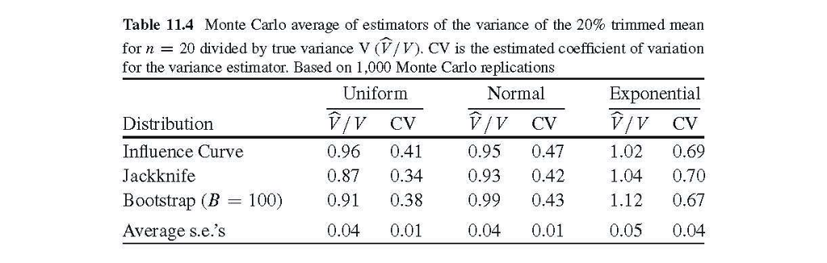

Under the uniform distribution, the estimated CVs are 0.41, 0.34, and 0.38. With an approximate SE of 0.01, these three CVs are reasonably well-separated (“significantly different”). However, for the other two distributions, the CVs are not as well-separeated compared to their SEs. In such a case, one might be interested in the standard errors of the differences or of the ratios of the CVs, because the these latter standard errors should be less than if the summaries were independent. The function pairwise.se is designed to get all pairwise SEs.

Here we display the first line of the function:

```
pairwise.se <- function(x,xcol,diff=TRUE,digits=4,B=0,seed=NULL,summary.f,...){
```

We see the main arguments are the Monte Carlo raw output data `x`, the columns `xcol` of `x` to use, and the summary `summary.f`. Here, `summary.f` is just a simple function of one vector as used in `mc.se.vector`. In the example below, we use `summary.f=CV`.

To illustrate pairwise.se, we first get the standard errors of the differences of CV values in Table 11.4 for the normal distribution using columns 6-8 of the output data frame `hold`.

```
> pairwise.se(hold,xcol=6:8,summary.f=cv)
  elem  summi  summj summary     se  t.stat    N    method
1  6 7 0.4695 0.4232  0.0463 0.0072  6.4254 1000 Jackknife
2  6 8 0.4695 0.4359  0.0337 0.0090  3.7556 1000 Jackknife
3  7 8 0.4232 0.4359 -0.0126 0.0071 -1.7795 1000 Jackknife
```

First notice that the summaries (0.47, 0.42, 0.43) for the normal distribution in Table 11.4  
show up under `summi` and `summj`. Then their differences are listed under `summary`. The standard errors of the differences are under `se`. Next, `t.stat` is `summary/se` if differences are used and `(summary-1)/se` if ratios are used (`diff=F`). To illustrate the use of ratios,

```
> pairwise.se(hold,xcol=6:8,diff=F,summary.f=cv)
  elem  summi  summj summary     se  t.stat    N    method
1  6 7 0.4695 0.4232  1.1095 0.0178  6.1676 1000 Jackknife
2  6 8 0.4695 0.4359  1.0773 0.0216  3.5719 1000 Jackknife
3  7 8 0.4232 0.4359  0.9710 0.0160 -1.8174 1000 Jackknife
```

Notice that `summi` and `summj` are the same as for differences, but now `summary` holds the ratios. The t statistics are similar to those for differences.  
If the bootstrap is to be used in place of the jackknife, we have

```
> pairwise.se(hold,xcol=6:8,B=1000,seed=769,summary.f=cv)
  elem  summi  summj summary     se  t.stat    B seed    N    method
1  6 7 0.4695 0.4232  0.0463 0.0070  6.5859 1000  769 1000 Bootstrap
2  6 8 0.4695 0.4359  0.0337 0.0090  3.7520 1000  769 1000 Bootstrap
3  7 8 0.4232 0.4359 -0.0126 0.0068 -1.8640 1000  769 1000 Bootstrap

> pairwise.se(hold,xcol=6:8,diff=F,B=1000,seed=769,summary.f=cv)
  elem  summi  summj summary     se  t.stat    B seed    N    method
1  6 7 0.4695 0.4232  1.1095 0.0178  6.1481 1000  769 1000 Bootstrap
2  6 8 0.4695 0.4359  1.0773 0.0211  3.6563 1000  769 1000 Bootstrap
3  7 8 0.4232 0.4359  0.9710 0.0160 -1.8179 1000  769 1000 Bootstrap
```

# Simulation Code

```
trim20 <- function(x){mean(x,.2)} # 20% trimmed mean function
trim.var <- function(x,trim){     # var. est. for trim20
  n <- length(x);h<-floor(trim*n)
  tm <- mean(x,trim);sort(x)->x
  ss <- h*((x[h+1]-tm)^2+(x[n-h]-tm)^2)
  ss <- ss+sum((x[(h+1):(n-h)]-tm)^2)
  ss/((n-2*h)*(n-2*h-1))
}
trim20.var<-function(x){trim.var(x,.2)}

N=1000
hold <- matrix(0,nrow=N,ncol=12)

set.seed(351)
 z <- matrix(runif(N*20),nrow=N)
 hold[,1] <- apply(z,1,trim20)
 hold[,2] <- apply(z,1,trim20.var)
 hold[,3] <- apply(z,1,jack.var,theta=trim20)
 hold[,4] <- apply(z,1,boot.var,theta=trim20,B=100)

set.seed(352)
z<- matrix(rnorm(N*20),nrow=N)
 hold[,5] <- apply(z,1,trim20)
 hold[,6] <- apply(z,1,trim20.var)
 hold[,7] <- apply(z,1,jack.var,theta=trim20)
 hold[,8] <- apply(z,1,boot.var,theta=trim20,B=100)

set.seed(353)
z<- matrix(rexp(N*20),nrow=N)
 hold[,9] <- apply(z,1,trim20)
 hold[,10] <- apply(z,1,trim20.var)
 hold[,11] <- apply(z,1,jack.var,theta=trim20)
 hold[,12] <- apply(z,1,boot.var,theta=trim20,B=100)
```